# R Notebook

```r
library(tidyverse)
# contains data on the energy production for different sectors in Scotland over time
energy_scotland <- read_csv("data/energy_scotland.csv")
# contains information on employees in a company
all_salaries <- read_csv("data/all_salaries.csv")
```

1. return the row in the data which has the maximum energy production, making sure the code would work if new data was added to the dataset.

```r
# ORIGINAL CODE
max(energy_scotland$energy_prod)
```

```
[1] 25165.9
```

```r
# this returns value 25165.9

energy_scotland %>%
  filter(energy_prod == 25165.9)
```

| year | sector | energy_prod |
| --- | --- | --- |
| 2017 | Renewables | 25165.9 |

```r
# REVIEWED & DEBUGGED CODE
energy_scotland %>%
  filter(energy_prod == max(energy_prod,  na.rm = TRUE))
```

| year | sector | energy_prod |
| --- | --- | --- |
| 2017 | Renewables | 25165.9 |

The code above is reusable. It finds which observation has the maximum energy production in the dataset. It won’t be looking into the rows with missing value for the energy production as the maximum entry for energy production is what we are interested in seeing.

```r
# ORIGINAL CODE
rating <- if_else(energy_scotland$energy_prod > 20000, "very high", if_else(energy_scotland$energy_prod > 10000 & energy_scotland$energy_prod <= 20000, "high", if_else(energy_scotland$energy_prod > 5000 & energy_scotland$energy_prod <= 10000, "medium", if_else(energy_scotland$energy_prod > 2000 & energy_scotland$energy_prod <= 5000, "low", "very low"))))

energy_scotland_rating <- bind_cols(energy_scotland, rating = rating)

# REVIEWED & DEBUGGED CODE
energy_scotland <- energy_scotland %>%
  mutate(rating = case_when(
    energy_prod > 20000 ~ "very high",
    energy_prod > 10000 ~ "high",
    energy_prod > 5000  ~ "medium",
    energy_prod > 2000  ~ "low",
    energy_prod <= 2000 ~ "Very low",
    TRUE ~ as.character(energy_prod)
  ))
```

I have created a new column called ‘rating’ which stores the description of energy production. Code is written in one single code chunk. The main difference/benefit of my code is reproducability. It is important to have clean and easily readable code.

3. Create a plot which shows how the energy production for the sectors renewables, gas and pumped hydro compare over time.

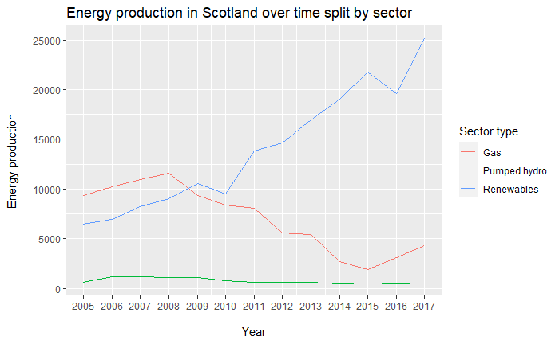

Instead of selecting and assigning three sector groups into individual variables. I would suggest to filter only required sectors and then use ‘group by’ function from ‘dplyr’ package (which groups by the sector - renewables, gas and pumped hydro).

4. Calculate the average energy production for each sector across the time period in the data.

| sector | avg_energy_prod |
| --- | --- |
| Coal | 10444.6023 |
| Gas | 7010.0615 |
| Nuclear | 16654.7308 |
| Oil | 1154.6815 |
| Pumped hydro | 760.8808 |
| Renewables | 13989.6377 |

The original code doesn’t completely answer the question. The question is asking to calculate average energy production for each sector. The original code printed only average energy production for three sectors and there are six sectors in total. From the original code, I removed the line with the filter function. This line excluded three other sectors in the data.

```r
student <- tibble(
  Name = c("Brian", "David", "Karen"),
  age = c(25, 56, 40),
  location = c("Scotland", "England", "scotland"),
  `email address` = c("briang@yahoo.co.uk", "dsmith@gmail.co.uk", "karen")
)

student
```

| Name | age | location | email address |
| --- | --- | --- | --- |
| Brian | 25 | Scotland | briang@yahoo.co.uk |
| David | 56 | England | dsmith@gmail.co.uk |
| Karen | 40 | scotland | karen |

Clean up this tibble by only returning the name, location and email address information, putting the location information into lowercase and also creating a new column called valid_email to have values TRUE or FALSE whether the email address is valid. Here our definition is valid is that it contains an @ symbol followed by a combination of lowercase characters or a . symbol.

| name | location | email_address | valid_email |
| --- | --- | --- | --- |
| Brian | scotland | briang@yahoo.co.uk | TRUE |
| David | england | dsmith@gmail.co.uk | TRUE |
| Karen | scotland | karen | FALSE |

The code selects ‘name’ column but the column is called ‘Name’. I would suggest to always run function ‘clean_names’ first. The fourth line of code is missing a pipe ( %>% ) and function str_to_lower needs to be inside a mutate function as we want to make changes to the column in the datatable. The last line there is a bracket missing at the end of the line. We need to place regular expressions inside []. The original code was looking for exact string match.

6. Create a function to work on the all_salaries dataframe (or a similar dataframe that has a column salary and job_area). The function should take in the dataframe (dataframe_input) and a job area (job_area_input) and a salary value (salary_input). The function should only return the employees in the dataframe that have a savings above this value salary_input and who work in job area job_area_input.

[output not shown]

[output cut: 110 more lines]

```r
subsetting_salaries <- function(dataframe_input, job_area_input, salary_input){
  results <- dataframe_input %>%
    filter(job_area == job_area_input) %>%
    filter(savings > salary_input)
  return(results)
}
subsetting_salaries(all_salaries, 'Legal', 30000)

subsetting_salaries(all_salaries, 'Human Resources', 20000)
```

| gender | name | surname | job_area | salary | age | retired | location | savings |
| --- | --- | --- | --- | --- | --- | --- | --- | --- |
| Female | Florence | Johnson | Human Resources | 22000 | 46 | No | Shetland | 31394 |
| Male | Freddy | Williamson | Human Resources | 16000 | 70 | Yes | Edinburgh | 41067 |
| Female | Florence | Thomason | Human Resources | 21000 | 42 | No | Aberdeen | 39691 |
| Male | Gord | Peterson | Human Resources | 16000 | 43 | No | Edinburgh | 33664 |
| Male | Harry | Mowat | Human Resources | 21000 | 67 | Yes | Western Isles | 37275 |
| Female | Cara | Henderson | Human Resources | 27000 | 79 | Yes | Edinburgh | 24720 |
| Male | Gord | Henderson | Human Resources | 29000 | 37 | No | Shetland | 48863 |
| Male | Angus | Henderson | Human Resources | 17000 | 51 | No | Orkney | 36078 |
| Male | Bert | Manson | Human Resources | 28000 | 58 | No | Western Isles | 37303 |
| Female | India | Smith | Human Resources | 17000 | 46 | No | Aberdeen | 23462 |

[output cut: 168 more lines]

The original code had some mistakes in it like selecting only one column (job_area) when we are interested in seeing whole table; missing quotations around Human Resources. I simplified the function by using tidyverse pipe functionality and filter function.